# Edward R. Tufte

## Edward R. Tufte

Statistician, Artist, and Professor Emeritus  
Website: edwardtufte.com  
Email: noreply@edwardtufte.com

[PDF version is available! Click me!]

Research in statistical evidence and analytical design for information visualization, integrating principles from statistics, graphic design, and cognitive science for the effective presentation of quantitative data.

### Experience

- **1983–Present**: Founder & Publisher, Graphics Press. Independent publishing house specializing in information design and data visualization.
- **1977–1999**: Professor Emeritus, Yale University. Departments of Political Science, Statistics, and Computer Science.
- **1967–1977**: Instructor, Princeton University. Woodrow Wilson School of Public and International Affairs.

### Artworks

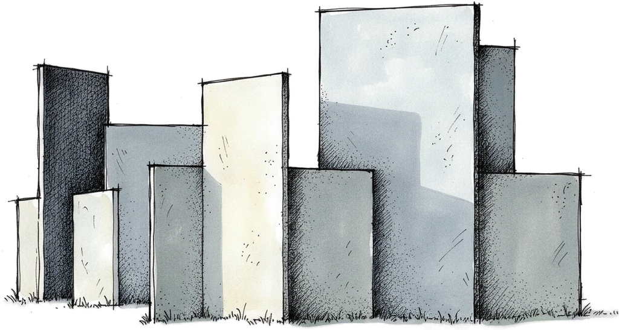

A homage to Edward R. Tufte’s large stainless steel sculpture titled *Escaping Flatland*

Founder of Hogpen Hill Farms, a 234-acre sculpture park in Woodbury, Connecticut. Creator of large-scale works including *Larkin’s Twig* and the *Escaping Flatland* series, exhibited at the Aldrich Contemporary Art Museum.

### Research Contributions

Development of sparklines, a method for embedding high-resolution data graphics within text, and formulation of the data-ink ratio as a quantitative measure of graphical efficiency.

### Books

- **2006**: *Beautiful Evidence*
- **1997**: *Visual Explanations: Images and Quantities, Evidence and Narrative*
- **1990**: *Envisioning Information*
- **1983**: *The Visual Display of Quantitative Information*

### Papers

- Tufte, Edward R., “Determinants of the Outcomes of Midterm Congressional Elections,” *American Political Science Review*, 1975. DOI: 10.2307/1958391
- Tufte, Edward R., “The Relationship between Seats and Votes in Two-Party Systems,” *American Political Science Review*, 1973. DOI: 10.2307/1958782

### Education

- PhD in Political Science: Yale University (1968).
- MS in Statistics: Stanford University.
- BS in Statistics: Stanford University.